# Chapter 8 — Logistic regression

Predicting a yes or no outcome in Molecular Biosciences

**Biostatistics · Molecular Biosciences**  
This chapter introduces **logistic regression**: predicting a yes or no outcome from a measured predictor. One experiment is followed from start to finish: mice given increasing doses of a bacterium, infected or not infected.

## Learning goals

By the end of this chapter, you should be able to:

- recognise when the outcome is yes or no and logistic regression is the right tool;
- explain probability, odds and log-odds;
- interpret the slope as a log odds ratio and report the odds ratio with its interval;
- state the hypotheses and assumptions, and run the Wald and likelihood-ratio tests;
- check the model with a calibration plot and the predicted risks;
- estimate the dose that infects half of the animals (ID50);
- run the analysis in R.

## Biological question: how does infection depend on dose?

Thirty-six mice are divided into six groups of six. Each group receives a different dose of a bacterium, from 10² to 10⁷ colony-forming units (CFU). After a week each mouse is classed as **infected** or **not infected**. **This one experiment is used throughout the chapter.**

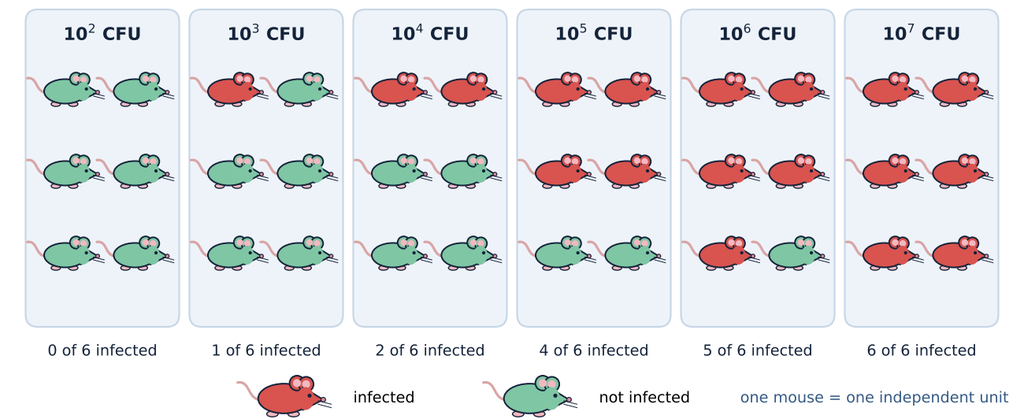

Six doses of bacteria, six mice per dose; red mice are infected.

The outcome has only two values, so a straight line is the wrong model: it would predict probabilities below 0 or above 1. Logistic regression models the **probability of infection** with an S-shaped curve.

**What to tell the analyst when you submit data.** Say what one row is (here, one mouse) and what the outcome is. Give the dose as a number, not as a label. Say how many animals were in each group and whether any were housed together in a cage: mice in the same cage are not independent. Report the range of doses tested: predictions are only valid inside it.

## Choosing the method

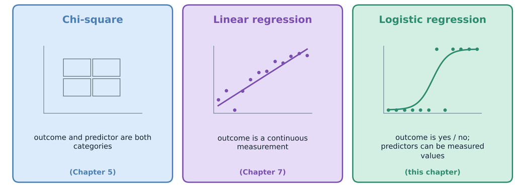

Chi-square compares categories, linear regression predicts a continuous outcome, logistic regression predicts a yes or no outcome.

- **Chi-square (Chapter 5):** outcome and predictor are both categories.
- **Linear regression (Chapter 7):** the outcome is a continuous measurement.
- **Logistic regression:** the outcome is yes or no and the predictor can be a measured value (or several predictors).

## Assumptions and hypotheses

The assumptions of logistic regression are:

- **Binary outcome:** each observation is yes or no.
- **Independence:** every row is a different, independent animal.
- **Linearity on the log-odds scale:** the log-odds of the outcome change in a straight line with the predictor.
- **Enough events:** a rough rule is at least 10 of the rarer outcome for each predictor in the model.

There is **no** normality or equal-variance assumption for the residuals. The hypotheses for the slope are:

$$H_0:\ \beta_1=0\quad\text{(the dose does not change the odds of
infection)}$$

$$H_1:\ \beta_1\neq0\quad\text{(the dose changes the odds of infection)}$$

### Model and R code

With $p$ the probability of infection, the model is

$$\log\frac{p}{1-p}=\beta_0+\beta_1\,x$$

In R:

```r
fit <- glm(infected ~ dose, family = binomial)
summary(fit)
```

## Worked example: probability, odds and log-odds

The **odds** are $p/(1-p)$: at $p=0.5$ the odds are 1, at $p=0.8$ they are 4. The **log-odds** (logit) can take any value, which is why a straight line can be fitted to them. The fitted model is

$$\log\frac{p}{1-p}=-6.17+1.37\times\text{dose}$$

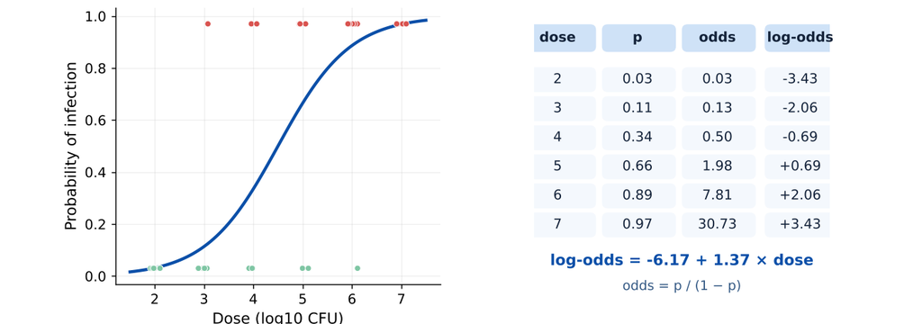

Left: the 36 mice and the fitted S-curve. Right: probability, odds and log-odds at each dose.

The log-odds rise by the same amount (1.37) for each extra log10 unit of dose, whereas the probability does not: it changes slowly at the extremes and fastest near 50%. At dose 10³ the model gives $p=0.11$.

## Estimating the coefficients: maximum likelihood

Logistic regression has no closed formula like least squares. The coefficients are found by **maximum likelihood**: the values that make the observed pattern of infected and healthy mice most probable. Software searches for them iteratively.

The standard error of the slope is 0.42. The **Wald test** divides the estimate by its standard error:

$$z=\frac{b_1}{SE(b_1)}=\frac{1.37}{0.42}=3.26,\qquad p=0.0011$$

## The likelihood-ratio test and a permutation check

A better test compares the fitted model with a model without dose. Twice the difference of their log-likelihoods is the **likelihood-ratio statistic**, which follows a chi-square distribution with 1 degree of freedom when $H_0$ is true:

$$LR=-2\,(\ell_0-\ell_1)=22.7,\qquad p=1.8e-06$$

To check this without relying on the chi-square approximation, shuffle the 36 outcomes at random across the doses, refit, and record the statistic. This was done 20,000 times.

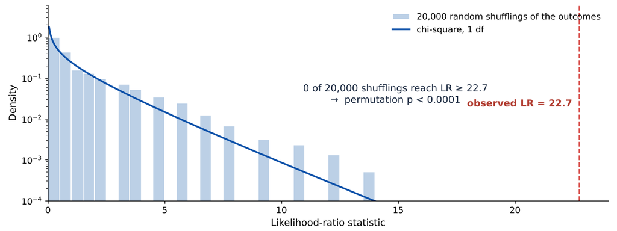

Likelihood-ratio statistics from 20,000 random shufflings (log scale) and the chi-square curve; the observed value is far to the right.

Only 0 of the 20,000 shufflings reaches the observed statistic, so the permutation p-value is below 0.0001 (strictly, it is less than $1/20,000$, and it is never reported as exactly zero).

The Wald test is quick but can be unreliable with small groups or extreme probabilities. The likelihood-ratio test is preferred, and it is the one that `anova(fit, test = "Chisq")` gives.

## Checking the model: calibration and predicted risk

A significant p-value does not show that the model describes the data well.

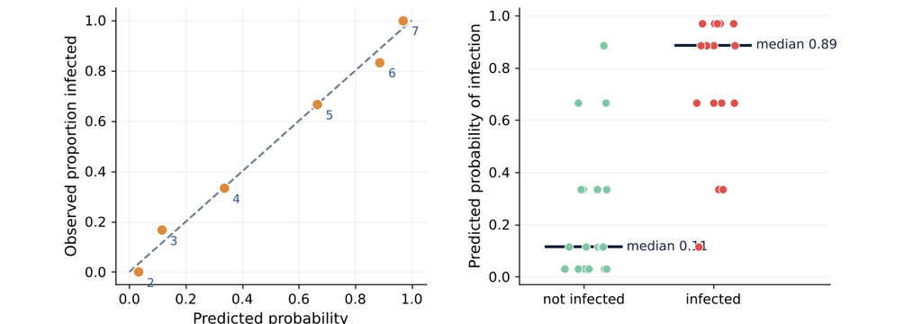

Left: predicted probability against the observed proportion infected at each dose. Right: predicted probability of each mouse, by outcome.

- **Calibration:** the points should lie close to the diagonal. They do, so the S-curve fits the six dose groups.
- **Predicted risk:** infected mice should receive higher predicted probabilities than healthy mice. Here the infected mice have a clearly higher median predicted probability, although the two groups overlap: some healthy mice at high doses and some infected mice at low doses are not predicted well.
- **McFadden pseudo-$R^2$** = 0.46. This is not the share of variance explained and is not comparable with the $R^2$ of linear regression.

## Effect size: the odds ratio

Exponentiating the slope gives the **odds ratio** for one unit of the predictor:

$$OR=e^{b_1}=e^{1.37}=3.94$$

Each 10-fold increase in dose multiplies the odds of infection by about 3.94. The 95% profile-likelihood interval is 1.99 to 10.98 (the Wald interval, 1.73 to 8.96, is narrower and less reliable here).

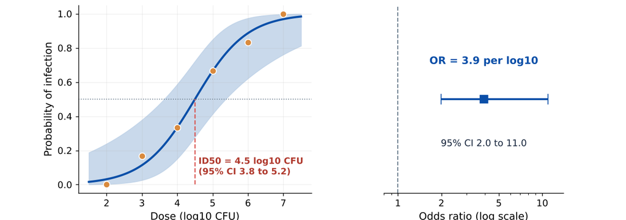

Left: fitted probability with its 95% band and the ID50. Right: odds ratio on a log scale.

An odds ratio is **not** a risk ratio: they are close only when the event is rare. Report the odds ratio with its interval, and say which unit of the predictor it refers to.

The **ID50** is the dose at which $p=0.5$, i.e. where the log-odds equal zero: $x=-b_0/b_1=4.5$ log10 CFU (95% CI 3.8 to 5.2, delta method).

Never predict outside the range of doses tested (10² to 10⁷ CFU here). Logistic regression also does not prove that the dose causes infection: it describes how the two go together in this experiment.

## R practical: run the analysis in your browser

**Editable R code**

Change the data or code, then select Run R.

[output not shown]

### R interpretation exercise: too few animals

The slope is still positive ($b_1=0.605$), but its standard error is large (0.384), the Wald $p=0.116$ and the odds ratio is 1.83 with a 95% interval of 0.86 to 3.89, which includes 1. The data are compatible with no effect of dose. A non-significant result from a small experiment is not evidence that the dose has no effect: it shows that the experiment had too little information.

## Practice questions

Answer the questions online and check the feedback. These questions are formative: use the explanations to review the relevant sections.

**1. Which question calls for logistic regression?**

- A. How much does absorbance increase per µg/mL of protein?
- B. Do two groups of cell lines differ in median expression?
- C. How does the probability of infection change with bacterial dose?
- D. Do three conditions differ within the same donors?

**2. A mouse has an 80% probability of infection. What are the odds of infection?**

- A. 0.8
- B. 4
- C. 0.25
- D. 1.25

**3. What does exp(b₁) represent in logistic regression?**

- A. The change in probability per unit of x
- B. The probability when x = 0
- C. The share of variance explained
- D. The odds ratio for one unit increase in the predictor

## Practice questions: odds and the model

**4. The slope is b₁ = 1.37 per log10 CFU. How is it interpreted?**

- A. Each 10-fold increase in dose multiplies the odds of infection by about 3.9
- B. Each 10-fold increase in dose adds 1.37 percentage points to the probability
- C. 137% of mice are infected
- D. The correlation between dose and infection is 1.37

**5. What does the likelihood-ratio test for the slope compare?**

- A. Observed and expected counts in a table
- B. The ranks of two groups
- C. The model with dose against the model without dose
- D. The residuals with a normal distribution

**6. In the calibration plot the six points lie close to the diagonal. What does this mean?**

- A. The slope is not significant
- B. The predicted probabilities agree well with the observed proportions infected
- C. The dose has no effect
- D. The model explains 100% of the variance

## Practice questions: testing and checking

**7. Which problem makes the p-value of a logistic regression unreliable?**

- A. The outcome has two categories
- B. The dose is a number
- C. The residuals are not normal
- D. Several mice share a cage and are treated as independent animals

**8. How is the dose that infects half of the mice (ID50) obtained?**

- A. Solve for the dose where the log-odds equal zero: −b₀/b₁
- B. Take the median dose tested
- C. Take the dose with the lowest p-value
- D. Take the highest dose

**9. Mice were housed six per cage, one cage per dose, and each mouse was entered as a separate row. Which assumption of logistic regression is broken?**

- A. Linearity on the log-odds scale
- B. Binary outcome
- C. Independence: mice in the same cage share their environment
- D. Normal residuals

**Interpretation reminder.** Report the odds ratio with its confidence interval and the unit of the predictor, check calibration, and remember that an odds ratio is not a risk ratio and that a model does not prove causation.

## Student notes

Use this space to record your interpretation, questions or reminders. Notes are saved locally in the current browser and device; they are not synchronised between devices.

Notes are stored locally in this browser.

## Chapter recap: the complete infographic

The infographic below summarises the whole chapter. Use it to review the biological question, method choice, assumptions, hypotheses, odds and log-odds, tests, model checks, odds ratio and ID50.

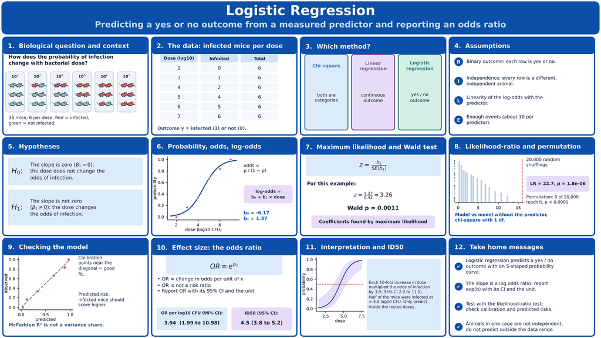

Logistic regression chapter infographic recap with twelve panels

**End of Chapter 8 · Biostatistics for Molecular Biosciences**